# A primer on statistical outbreak analysis

2017-12-09

## Introduction

## Early outbreak context

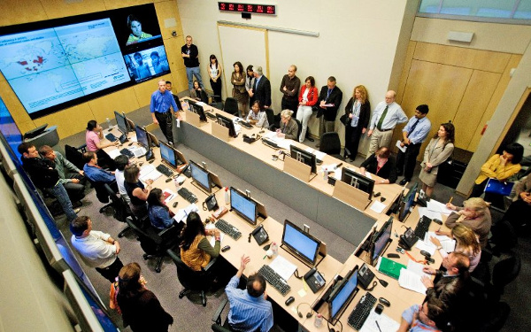

- within a few days / weeks of index case
- limited data available
- no or limited intervention
- no depletion of susceptibles
- urgent assessment needed to inform response

## Data usually available

- dates of symptom onset
- contact data: exposure (*who infected you?*) and contact tracing (*who could you have infected?*)
- dates of exposure / infection
- dates of outcome: death / recovery
- metadata on patients: age, gender, location, occupation, etc.
- data from past outbreaks

## Key questions

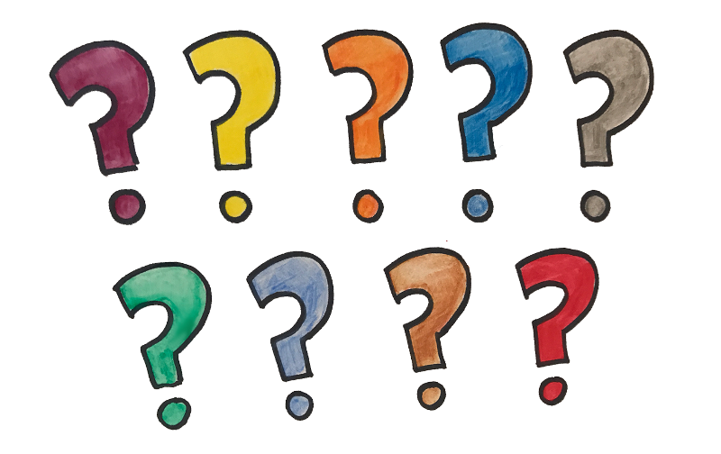

Disease-dependent, but generally includes:

- How fast is it growing?
- What is driving the epidemic growth?
- What is the case fatality ratio?
- Who is most severely affected?
- How many cases should we expect in the next days / weeks?
- …

## Estimating key delays

## The incubation period

**Definition:** time interval between the date on infection and the date of symptom onset

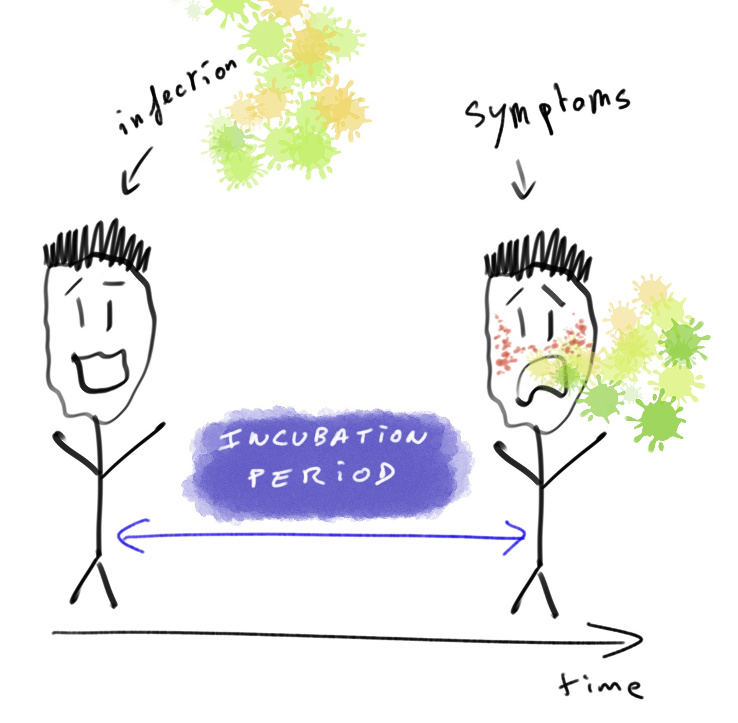

## The serial interval

**Definition:** time interval between onset of symptoms in primary and secondary cases.

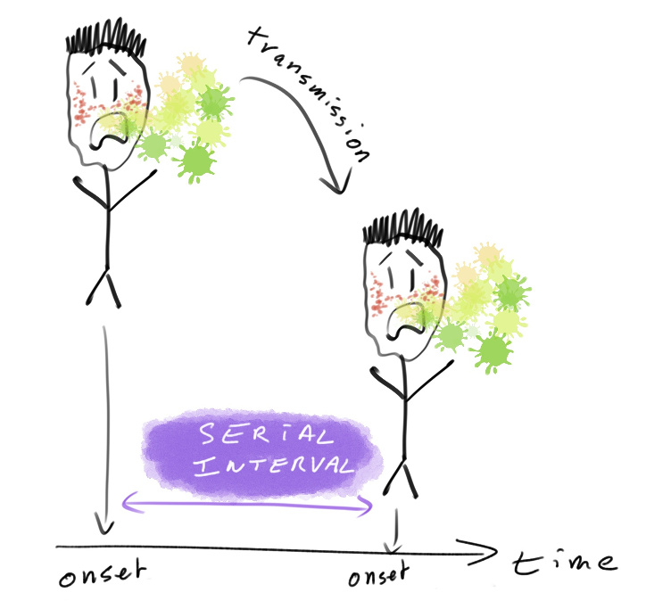

## The generation time

**Definition:** time interval between date of infections in primary and secondary cases.

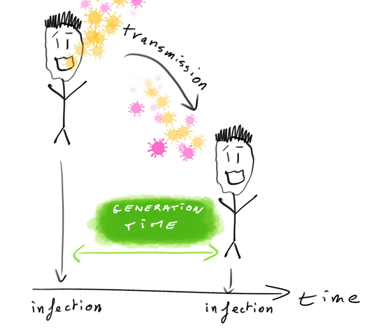

## Estimating the underlying distribution

From empirical distribution (data) to estimated distribution.

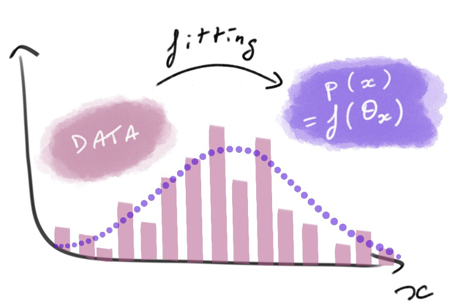

- choose type of distribution (e.g. normal, Poisson, Gamma)
- find \(\theta_x\) which maximise \(p(x)\), i.e. the likelihood
- visually: best fit between bars (data) and curve (distribution)

## Discretising continuous distributions

Using continuous distributions to model discrete variables:

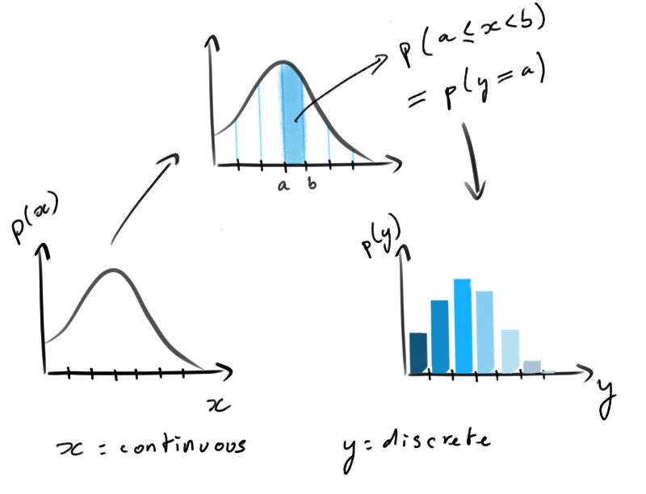

## Fitting discretised Gamma distributions for delays

- flexible distribution (many shapes possibles)
- 2 parameters: *shape*, *scale*
- alternatively: *mean*, *coefficient of variation*
- typical choice for delay distributions
- needs to be discretised

## Estimating mortality

## Case fatality ratio

**Definition:** the proportion of cases who die of the infection.

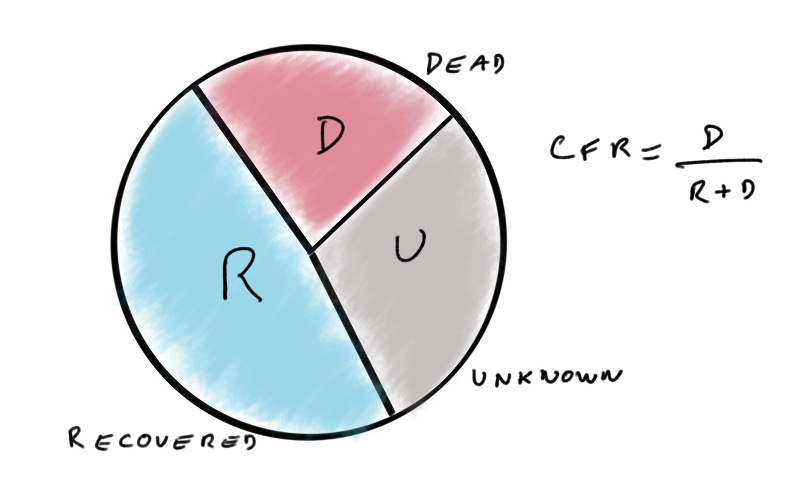

## Associated uncertainty

- CFR = mean number of death per case \(\rightarrow\) confidence interval is Normally distributed
- standard error: \[ s_{CFR} = \sqrt{\frac{CFR (1 - CFR)}{N}} \] with \(N = D + R\) (number of cases with known outcomes)
- confidence interval with \(\alpha\) threshold: \[ CI_{(1-\alpha)\%} = CFR \pm s_{CFR} \times Q_{1-\alpha/2} \]

where \(Q\) is a Normal quantile (e.g. \(1.96\) for \(\alpha=0.05\))

## Example: confidence intervals of CFR

- CFR: 60%, N = 10: \[ s_{CFR} = \sqrt{\frac{0.6 \times 0.4}{10}} = 0.155 \]

- CFR: 60%, N = 100: \[ s_{CFR} = \sqrt{\frac{0.6 \times 0.4}{100}} = 0.05 \]

\[ CI_{95\%} = 0.6 \pm 1.96 \times 0.05 = [0.50 ; 0.70] \]

## Common caveats

- "*case fatality rate*": this is a proportion, not a rate
- computation using wrong denominator, i.e. including unknown outcome:

\[ \frac{D}{D + R + U} \]

(leads to underestimating the CFR)

- not accounting for uncertainty, e.g. comparing CFR across groups without statistical tests

## Analysing incidence data

## What is incidence?

**Definition:** the incidence is the number of new cases on a given time period.

- relies on dates, typically of onset of symptoms
- only daily incidence is non-ambiguous
- other definitions (e.g. weekly) rely on a starting date
- prone to reporting delays

## Log-linear model of incidence

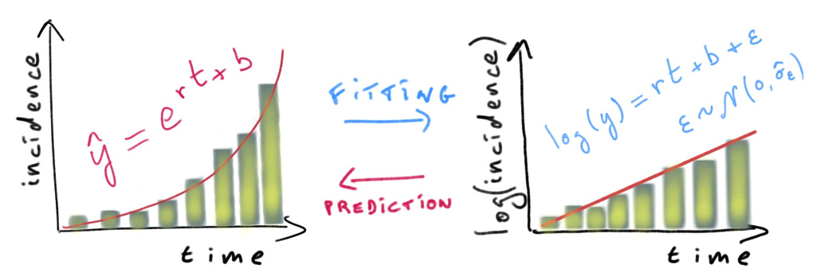

\(log(y) = r \times t + b + \epsilon\:\:\) so that \(\:\:\hat{y} = e^{r \times t + b}\)

with:

- \(r\): growth rate
- b: intercept
- \(\epsilon \sim \mathcal{N}(0, \hat{\sigma_{\epsilon}})\)

## Doubling time

Let \(T\) be the time taken by the incidence to double, given a daily growth rate \(r\).

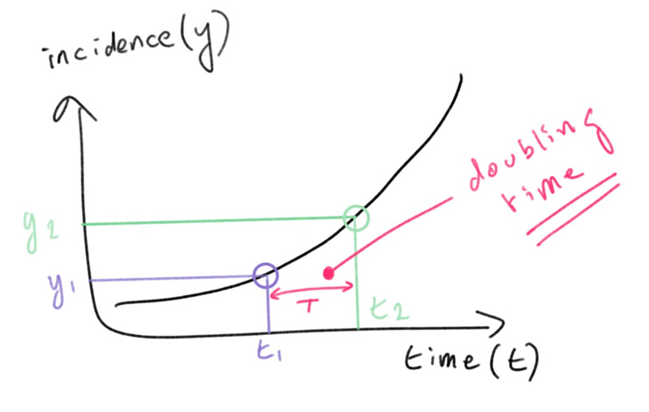

\[ y_2 / y_1 = 2 \:\: \Leftrightarrow e^{rt_2 + b} / e^{rt_1 + b} = 2 \]

\[ \Leftrightarrow e^{r(t_2 - t_1)} = 2 \Leftrightarrow T = log(2) / r \]

## Log-linear model: pros and cons

**Pros**:

- fast and simple
- predictions possible
- doubling / halving time readily available
- possible extensions to estimate \(R_0\) from \(r\)

**Cons**:

- zero incidence problematic
- non mechanistic
- no inclusion of other information (e.g. serial interval)

## Individual infectiousness over time

**Serial interal:** time interval between onset of symptoms of primary and secondary cases.

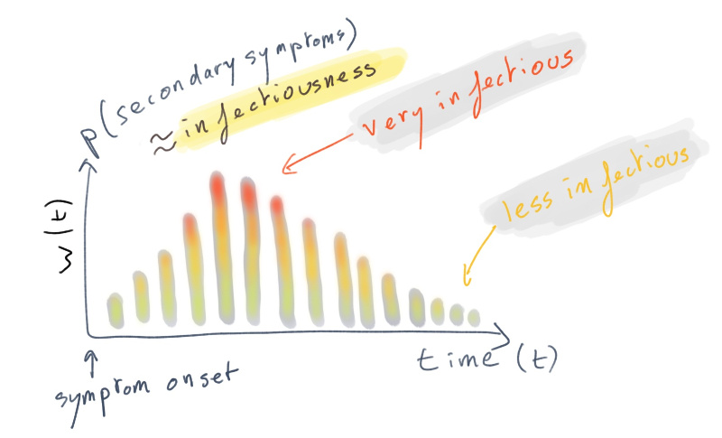

## Global infectiousness over time

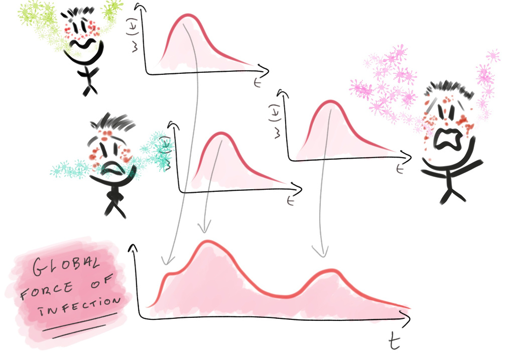

\[ \lambda_t = R_0 \times \sum_i w(t - t_i) \]

with: \(\lambda_t\): global force of infection; \(w()\): serial interval distribution; \(t_i\): date of symptom onset

## A Poisson model of incidence

[figure not shown]

Treat incidence \(y_t\) on day \(t\) as a Poisson distribution of rate \(\lambda_t\):

\[ p(y_t | R_0, y_1, ..., y_{t-1}) = e^{-\lambda_t} \frac{\lambda_t^{y_t}}{(!y_t)} \] with (slight rewriting): \(\lambda_t = R_0 \times \sum_{s = 1}^{t-1} y_s w(t - s)\)

## Poisson model: pros and cons

**Pros**:

- still fast, reasonably simple (1 parameter)
- accommodates zero incidence
- predictions possible: forward simulation (Poisson)
- integrates information on serial interval
- extension to time-varying \(R\) (*EpiEstim*)

**Cons**:

- needs information on serial interval
- no spatial processes
- assumes constant reporting
- likelihood / Bayesian methods harder to communicate

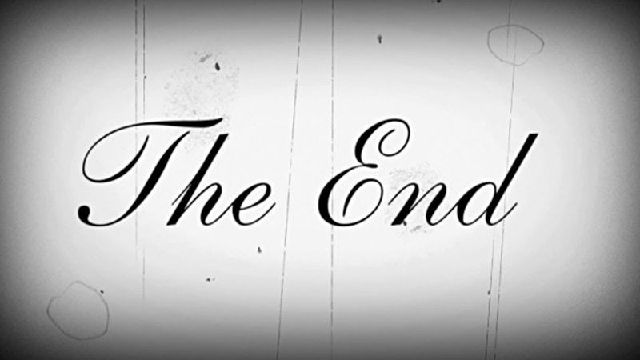